# Subgroup Identification Analysis

Applications to consistency analyses in MRCTs

Author

Larry Leon

```r
# Set options
knitr::opts_chunk$set(
  echo = TRUE,
  warning = FALSE,
  message = FALSE,
  fig.align = 'center',
  fig.retina = 2
)
rm(list=ls())
library(tinytex)
library(ggplot2)
library(table1)

library(gt)

# test these packages
# just for testing any conflicts
# library(tidyverse)
# library(plyr)
# library(dplyr)
# library(glmnet)

library(survival)
library(data.table)
library(randomForest)
library(grf)
library(policytree)
library(DiagrammeR)

library(grid)
library(forestploter)
library(randomizr)

# library(devtools)
# install_github("larry-leon/weightedsurv", force = TRUE)
# install_github("larry-leon/forestsearch", force = TRUE)


library(forestsearch)
library(weightedsurv)

#help(forestsearch)

#help(generate_aft_dgm_flex)

# Set theme for plots
theme_set(theme_minimal(base_size = 12))
```

# 1 Introduction

This document provides executable examples for the `generate_aft_dgm_flex()` function, demonstrating various use cases for creating synthetic survival data with flexible subgroup definitions.

```r
library(survival)
library(ggplot2)

# Load example data
data(gbsg, package = "survival")

# Preview the data
head(gbsg)
```

```
   pid age meno size grade nodes pgr er hormon rfstime status
1  132  49    0   18     2     2   0  0      0    1838      0
2 1575  55    1   20     3    16   0  0      0     403      1
3 1140  56    1   40     3     3   0  0      0    1603      0
4  769  45    0   25     3     1   0  4      0     177      0
5  130  65    1   30     2     5   0 36      1    1855      0
6 1642  48    0   52     2    11   0  0      0     842      1
```

# 2 Example 1: Basic Usage with Fixed Cutpoints

This example demonstrates the simplest usage with fixed value cutpoints.

```r
# Create DGM with fixed cutpoints
dgm1 <- generate_aft_dgm_flex(
  data = gbsg,
  continuous_vars = c("age", "size", "nodes", "pgr", "er"),
  factor_vars = c("meno", "grade"),
  outcome_var = "rfstime",
  event_var = "status",
  treatment_var = "hormon",
  subgroup_vars = c("er", "meno"),
  subgroup_cuts = list(
    er = 20,         # Fixed value: er <= 20
    meno = 0         # Factor level: meno == 0
  ),
  model = "alt",
  k_treat = 1.0,
  k_inter = 1.5,
  n_super = 5000,
  seed = 123,
  verbose = TRUE
)
```

```
=== Subgroup Definitions ===
   er <= 20
    Proportion in subgroup: 0.397
   meno <= 0
    Proportion in subgroup: 0.423

Overall subgroup (all conditions met):
  Size: 134 out of 686
  Proportion: 0.195

=== Model Parameters (AFT, log(T)) ===
Intercept (mu): 7.473
Scale (tau): 0.721
Treatment effect: 0.321
Interaction effect: -0.47

Overall subgroup in super-population (all conditions met):
  Proportion: 0.201

=== Hazard Ratios (super popln) ===
Overall HR: 0.785
Causal AHR: 0.731
Harm subgroup HR: 1.205
Harm subgroup AHR: 1.23
No-harm subgroup HR: 0.731
No-harm subgroup AHR: 0.641

 ======================================================================
 CENSORING MODEL SELECTION:
 MULTIPLE SURVIVAL REGRESSION MODEL COMPARISONS
======================================================================

CONVERGENCE SUMMARY ( 4 / 4  converged):
--------------------------------------------------

Weibull (weibull):
  Status:  ✓ Converged
  Iterations:  9
  Log-likelihood:  -3160.27
  Scale parameter:  0.418
```

[output cut: 27 more lines]

```
MODEL RANKINGS:
--------------------------------------------------
By AIC:  Weibull0 > Weibull > LogNormal0 > LogNormal
By BIC:  Weibull0 > Weibull > LogNormal0 > LogNormal

EVIDENCE ASSESSMENT:
--------------------------------------------------
  Strength:  Strong evidence
  Details:  Top model has 97.6% of AIC weight

FINAL RECOMMENDATION:
--------------------------------------------------
  Clear winner: Weibull0 (best by both AIC and BIC)
  Evidence: Strong evidence - Top model has 97.6% of AIC weight
======================================================================
```

## 2.1 Visualize Subgroup Definition

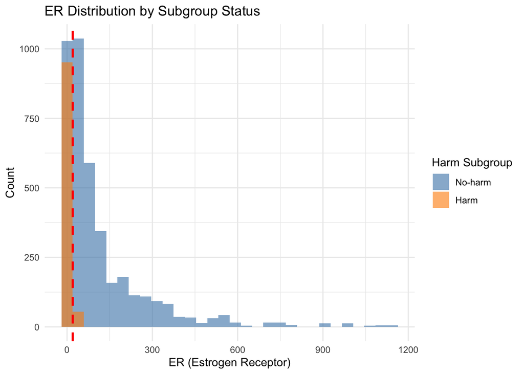

```r
# Check subgroup distribution
df_super <- dgm1$df_super

# Plot ER distribution by subgroup
ggplot(df_super, aes(x = z_er, fill = factor(flag_harm))) +
  geom_histogram(bins = 30, alpha = 0.6, position = "identity") +
  geom_vline(xintercept = 20, linetype = "dashed", color = "red", linewidth = 1) +
  labs(
    title = "ER Distribution by Subgroup Status",
    x = "ER (Estrogen Receptor)",
    y = "Count",
    fill = "Harm Subgroup"
  ) +
  scale_fill_manual(
    values = c("0" = "steelblue", "1" = "darkorange"),
    labels = c("0" = "No-harm", "1" = "Harm")
  ) +
  theme_minimal()
```

```r
# Summary statistics
cat("\nSubgroup Summary:\n")
```

```
Subgroup Summary:
```

```r
cat("Harm subgroup size:", dgm1$subgroup_info$size, "\n")
```

```
Harm subgroup size: 1007
```

```r
cat("Harm subgroup proportion:", round(dgm1$subgroup_info$proportion, 3), "\n")
```

```
Harm subgroup proportion: 0.201
```

```r
cat("Overall HR:", round(dgm1$hazard_ratios$overall, 3), "\n")
```

```
Overall HR: 0.785
```

```r
cat("Harm subgroup HR:", round(dgm1$hazard_ratios$harm_subgroup, 3), "\n")
```

```
Harm subgroup HR: 1.205
```

```r
cat("No-harm subgroup HR:", round(dgm1$hazard_ratios$no_harm_subgroup, 3), "\n")
```

```
No-harm subgroup HR: 0.731
```

# 3 Example 2: Quantile-Based Cutpoints

This example uses quantile-based cutpoints to define subgroups.

```r
# Create DGM with quantile cutpoints
dgm2 <- generate_aft_dgm_flex(
  data = gbsg,
  continuous_vars = c("age", "size", "nodes", "pgr", "er"),
  factor_vars = c("meno", "grade"),
  outcome_var = "rfstime",
  event_var = "status",
  treatment_var = "hormon",
  subgroup_vars = c("er", "pgr", "nodes"),
  subgroup_cuts = list(
    er = list(type = "quantile", value = 0.25),    # Bottom 25%
    pgr = list(type = "quantile", value = 0.33),   # Bottom 33%
    nodes = list(type = "quantile", value = 0.50)  # Bottom 50%
  ),
  model = "alt",
  k_treat = 1.0,
  k_inter = 2.0,
  n_super = 5000,
  seed = 456,
  verbose = TRUE
)
```

```
=== Subgroup Definitions ===
   er <= 8 ( 25 th percentile)
    Proportion in subgroup: 0.261
   pgr <= 13 ( 33 th percentile)
    Proportion in subgroup: 0.34
   nodes <= 3 ( 50 th percentile)
    Proportion in subgroup: 0.548

Overall subgroup (all conditions met):
  Size: 66 out of 686
  Proportion: 0.096

=== Model Parameters (AFT, log(T)) ===
Intercept (mu): 7.423
Scale (tau): 0.719
Treatment effect: 0.263
Interaction effect: 0.114

Overall subgroup in super-population (all conditions met):
  Proportion: 0.094

=== Hazard Ratios (super popln) ===
Overall HR: 0.755
Causal AHR: 0.683
Harm subgroup HR: 0.597
Harm subgroup AHR: 0.591
No-harm subgroup HR: 0.767
No-harm subgroup AHR: 0.693

 ======================================================================
 CENSORING MODEL SELECTION:
 MULTIPLE SURVIVAL REGRESSION MODEL COMPARISONS
======================================================================

CONVERGENCE SUMMARY ( 4 / 4  converged):
--------------------------------------------------

Weibull (weibull):
  Status:  ✓ Converged
  Iterations:  9
```

[output cut: 29 more lines]

```
MODEL RANKINGS:
--------------------------------------------------
By AIC:  Weibull0 > Weibull > LogNormal0 > LogNormal
By BIC:  Weibull0 > Weibull > LogNormal0 > LogNormal

EVIDENCE ASSESSMENT:
--------------------------------------------------
  Strength:  Strong evidence
  Details:  Top model has 97.6% of AIC weight

FINAL RECOMMENDATION:
--------------------------------------------------
  Clear winner: Weibull0 (best by both AIC and BIC)
  Evidence: Strong evidence - Top model has 97.6% of AIC weight
======================================================================
```

```r
# Compare subgroup definitions
cat("\nSubgroup Definitions:\n")
```

```
Subgroup Definitions:
```

```r
for (var in names(dgm2$subgroup_info$definitions)) {
  cat(var, ":", dgm2$subgroup_info$definitions[[var]], "\n")
}
```

```
er : er <= 8 ( 25 th percentile)
pgr : pgr <= 13 ( 33 th percentile)
nodes : nodes <= 3 ( 50 th percentile)
```

# 4 Example 3: Function-Based Cutpoints

This example uses statistical functions (median, mean) to define cutpoints.

```r
# Create DGM with function-based cutpoints
dgm3 <- generate_aft_dgm_flex(
  data = gbsg,
  continuous_vars = c("age", "size", "nodes", "pgr", "er"),
  factor_vars = c("meno", "grade"),
  outcome_var = "rfstime",
  event_var = "status",
  treatment_var = "hormon",
  subgroup_vars = c("age", "size"),
  subgroup_cuts = list(
    age = list(type = "function", fun = median),
    size = list(type = "function", fun = mean)
  ),
  model = "alt",
  k_treat = 0.8,
  k_inter = 1.8,
  n_super = 5000,
  seed = 789,
  verbose = TRUE
)
```

```
=== Subgroup Definitions ===
   age <= 53 ( cut_spec$fun )
    Proportion in subgroup: 0.529
   size <= 29.33 ( cut_spec$fun )
    Proportion in subgroup: 0.582

Overall subgroup (all conditions met):
  Size: 208 out of 686
  Proportion: 0.303

=== Model Parameters (AFT, log(T)) ===
Intercept (mu): 7.345
Scale (tau): 0.718
Treatment effect: 0.175
Interaction effect: 0.442

Overall subgroup in super-population (all conditions met):
  Proportion: 0.296

=== Hazard Ratios (super popln) ===
Overall HR: 0.718
Causal AHR: 0.653
Harm subgroup HR: 0.505
Harm subgroup AHR: 0.424
No-harm subgroup HR: 0.839
No-harm subgroup AHR: 0.784

 ======================================================================
 CENSORING MODEL SELECTION:
 MULTIPLE SURVIVAL REGRESSION MODEL COMPARISONS
======================================================================

CONVERGENCE SUMMARY ( 4 / 4  converged):
--------------------------------------------------

Weibull (weibull):
  Status:  ✓ Converged
  Iterations:  9
  Log-likelihood:  -3160.27
  Scale parameter:  0.418
```

[output cut: 27 more lines]

```
MODEL RANKINGS:
--------------------------------------------------
By AIC:  Weibull0 > Weibull > LogNormal0 > LogNormal
By BIC:  Weibull0 > Weibull > LogNormal0 > LogNormal

EVIDENCE ASSESSMENT:
--------------------------------------------------
  Strength:  Strong evidence
  Details:  Top model has 97.6% of AIC weight

FINAL RECOMMENDATION:
--------------------------------------------------
  Clear winner: Weibull0 (best by both AIC and BIC)
  Evidence: Strong evidence - Top model has 97.6% of AIC weight
======================================================================
```

```r
# Hazard ratio comparison
cat("\nHazard Ratios:\n")
```

```
Hazard Ratios:
```

```r
cat("Overall:", round(dgm3$hazard_ratios$overall, 3), "\n")
```

```
Overall: 0.718
```

```r
cat("Harm subgroup:", round(dgm3$hazard_ratios$harm_subgroup, 3), "\n")
```

```
Harm subgroup: 0.505
```

```r
cat("No-harm subgroup:", round(dgm3$hazard_ratios$no_harm_subgroup, 3), "\n")
```

```
No-harm subgroup: 0.839
```

# 5 Example 4: Range-Based Cutpoints

This example defines subgroups using value ranges.

```r
# Create DGM with range cutpoints
dgm4 <- generate_aft_dgm_flex(
  data = gbsg,
  continuous_vars = c("age", "size", "nodes", "pgr", "er"),
  factor_vars = c("meno", "grade"),
  outcome_var = "rfstime",
  event_var = "status",
  treatment_var = "hormon",
  subgroup_vars = c("age", "nodes"),
  subgroup_cuts = list(
    age = list(type = "range", min = 40, max = 60),
    nodes = list(type = "range", min = 0, max = 5)
  ),
  model = "alt",
  k_treat = 1.0,
  k_inter = 2.5,
  n_super = 5000,
  seed = 101,
  verbose = TRUE
)
```

```
=== Subgroup Definitions ===
   40 <= age <= 60
    Proportion in subgroup: 0.631
   0 <= nodes <= 5
    Proportion in subgroup: 0.691

Overall subgroup (all conditions met):
  Size: 298 out of 686
  Proportion: 0.434

=== Model Parameters (AFT, log(T)) ===
Intercept (mu): 7.371
Scale (tau): 0.718
Treatment effect: 0.201
Interaction effect: 0.518

Overall subgroup in super-population (all conditions met):
  Proportion: 0.445

=== Hazard Ratios (super popln) ===
Overall HR: 0.631
Causal AHR: 0.549
Harm subgroup HR: 0.47
Harm subgroup AHR: 0.368
No-harm subgroup HR: 0.815
No-harm subgroup AHR: 0.756

 ======================================================================
 CENSORING MODEL SELECTION:
 MULTIPLE SURVIVAL REGRESSION MODEL COMPARISONS
======================================================================

CONVERGENCE SUMMARY ( 4 / 4  converged):
--------------------------------------------------

Weibull (weibull):
  Status:  ✓ Converged
  Iterations:  9
  Log-likelihood:  -3160.27
  Scale parameter:  0.418
```

[output cut: 27 more lines]

```
MODEL RANKINGS:
--------------------------------------------------
By AIC:  Weibull0 > Weibull > LogNormal0 > LogNormal
By BIC:  Weibull0 > Weibull > LogNormal0 > LogNormal

EVIDENCE ASSESSMENT:
--------------------------------------------------
  Strength:  Strong evidence
  Details:  Top model has 97.6% of AIC weight

FINAL RECOMMENDATION:
--------------------------------------------------
  Clear winner: Weibull0 (best by both AIC and BIC)
  Evidence: Strong evidence - Top model has 97.6% of AIC weight
======================================================================
```

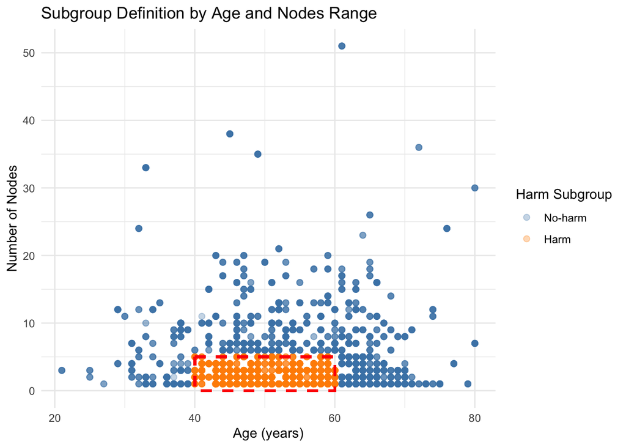

```r
# Visualize age range subgroup
df_super4 <- dgm4$df_super

ggplot(df_super4, aes(x = z_age, y = z_nodes, color = factor(flag_harm))) +
  geom_point(alpha = 0.3, size = 2) +
  geom_rect(
    aes(xmin = 40, xmax = 60, ymin = 0, ymax = 5),
    fill = NA, color = "red", linewidth = 1, linetype = "dashed",
    inherit.aes = FALSE
  ) +
  labs(
    title = "Subgroup Definition by Age and Nodes Range",
    x = "Age (years)",
    y = "Number of Nodes",
    color = "Harm Subgroup"
  ) +
  scale_color_manual(
    values = c("0" = "steelblue", "1" = "darkorange"),
    labels = c("0" = "No-harm", "1" = "Harm")
  ) +
  theme_minimal()
```

# 6 Example 5: Greater-Than Cutpoints

This example uses “greater than” specifications for subgroup definition.

```r
# Create DGM with "greater than" cutpoints
dgm5 <- generate_aft_dgm_flex(
  data = gbsg,
  continuous_vars = c("age", "size", "nodes", "pgr", "er"),
  factor_vars = c("meno", "grade"),
  outcome_var = "rfstime",
  event_var = "status",
  treatment_var = "hormon",
  subgroup_vars = c("nodes", "size"),
  subgroup_cuts = list(
    nodes = list(type = "greater", quantile = 0.75),  # Top 25%
    size = list(type = "greater", value = 30)          # size > 30
  ),
  model = "alt",
  k_treat = 1.0,
  k_inter = 1.5,
  n_super = 5000,
  seed = 202,
  verbose = TRUE
)
```

```
=== Subgroup Definitions ===
   nodes > 7
    Proportion in subgroup: 0.208
   size > 30
    Proportion in subgroup: 0.319

Overall subgroup (all conditions met):
  Size: 65 out of 686
  Proportion: 0.095

=== Model Parameters (AFT, log(T)) ===
Intercept (mu): 7.383
Scale (tau): 0.718
Treatment effect: 0.304
Interaction effect: -0.365

Overall subgroup in super-population (all conditions met):
  Proportion: 0.096

=== Hazard Ratios (super popln) ===
Overall HR: 0.746
Causal AHR: 0.687
Harm subgroup HR: 1.072
Harm subgroup AHR: 1.088
No-harm subgroup HR: 0.726
No-harm subgroup AHR: 0.655

 ======================================================================
 CENSORING MODEL SELECTION:
 MULTIPLE SURVIVAL REGRESSION MODEL COMPARISONS
======================================================================

CONVERGENCE SUMMARY ( 4 / 4  converged):
--------------------------------------------------

Weibull (weibull):
  Status:  ✓ Converged
  Iterations:  9
  Log-likelihood:  -3160.27
  Scale parameter:  0.418
```

[output cut: 27 more lines]

```
MODEL RANKINGS:
--------------------------------------------------
By AIC:  Weibull0 > Weibull > LogNormal0 > LogNormal
By BIC:  Weibull0 > Weibull > LogNormal0 > LogNormal

EVIDENCE ASSESSMENT:
--------------------------------------------------
  Strength:  Strong evidence
  Details:  Top model has 97.6% of AIC weight

FINAL RECOMMENDATION:
--------------------------------------------------
  Clear winner: Weibull0 (best by both AIC and BIC)
  Evidence: Strong evidence - Top model has 97.6% of AIC weight
======================================================================
```

```r
# Summary
cat("\nSubgroup characteristics:\n")
```

```
Subgroup characteristics:
```

```r
cat("Definition:", dgm5$subgroup_info$definitions$nodes, "\n")
```

```
Definition: nodes > 7
```

```r
cat("Definition:", dgm5$subgroup_info$definitions$size, "\n")
```

```
Definition: size > 30
```

```r
cat("Proportion:", round(dgm5$subgroup_info$proportion, 3), "\n")
```

```
Proportion: 0.096
```

# 7 Example 6: Multiple Factor Values

This example shows how to define subgroups using multiple categorical values.

```r
# Create DGM with multiple factor values
dgm6 <- generate_aft_dgm_flex(
  data = gbsg,
  continuous_vars = c("age", "size", "nodes", "pgr", "er"),
  factor_vars = c("meno", "grade"),
  outcome_var = "rfstime",
  event_var = "status",
  treatment_var = "hormon",
  subgroup_vars = c("grade", "meno"),
  subgroup_cuts = list(
    grade = list(type = "multiple", values = c(2, 3)),  # Grade 2 or 3
    meno = 0  # Premenopausal
  ),
  model = "alt",
  k_treat = 1.0,
  k_inter = 1.8,
  n_super = 5000,
  seed = 303,
  verbose = TRUE
)
```

```
=== Subgroup Definitions ===
   grade (unknown specification)
    Proportion in subgroup: 0.882
   meno <= 0
    Proportion in subgroup: 0.423

Overall subgroup (all conditions met):
  Size: 257 out of 686
  Proportion: 0.375

=== Model Parameters (AFT, log(T)) ===
Intercept (mu): 7.426
Scale (tau): 0.719
Treatment effect: 0.253
Interaction effect: 0.099

Overall subgroup in super-population (all conditions met):
  Proportion: 0.383

=== Hazard Ratios (super popln) ===
Overall HR: 0.75
Causal AHR: 0.667
Harm subgroup HR: 0.677
Harm subgroup AHR: 0.613
No-harm subgroup HR: 0.788
No-harm subgroup AHR: 0.703

 ======================================================================
 CENSORING MODEL SELECTION:
 MULTIPLE SURVIVAL REGRESSION MODEL COMPARISONS
======================================================================

CONVERGENCE SUMMARY ( 4 / 4  converged):
--------------------------------------------------

Weibull (weibull):
  Status:  ✓ Converged
  Iterations:  9
  Log-likelihood:  -3160.27
  Scale parameter:  0.418
```

[output cut: 27 more lines]

```
MODEL RANKINGS:
--------------------------------------------------
By AIC:  Weibull0 > Weibull > LogNormal0 > LogNormal
By BIC:  Weibull0 > Weibull > LogNormal0 > LogNormal

EVIDENCE ASSESSMENT:
--------------------------------------------------
  Strength:  Strong evidence
  Details:  Top model has 97.6% of AIC weight

FINAL RECOMMENDATION:
--------------------------------------------------
  Clear winner: Weibull0 (best by both AIC and BIC)
  Evidence: Strong evidence - Top model has 97.6% of AIC weight
======================================================================
```

```r
# Tabulate subgroup membership
df_super6 <- dgm6$df_super
table(Grade = df_super6$z_grade_1, Meno = df_super6$z_meno, Harm = df_super6$flag_harm)
```

```
, , Harm = 0

     Meno
Grade    0    1
    0    0 2513
    1  236  335

, , Harm = 1

     Meno
Grade    0    1
    0 1916    0
    1    0    0
```

# 8 Example 7: Null Model (No Subgroup Effects)

This example demonstrates the null model where there are no subgroup-specific effects.

```r
# Create null model DGM
dgm7_null <- generate_aft_dgm_flex(
  data = gbsg,
  continuous_vars = c("age", "size", "nodes", "pgr", "er"),
  factor_vars = c("meno", "grade"),
  outcome_var = "rfstime",
  event_var = "status",
  treatment_var = "hormon",
  subgroup_vars = NULL,  # No subgroups
  subgroup_cuts = NULL,
  model = "null",  # Null model
  k_treat = 1.0,
  n_super = 5000,
  seed = 404,
  verbose = TRUE
)
```

```
=== Model Parameters (AFT, log(T)) ===
Intercept (mu): 7.433
Scale (tau): 0.719
Treatment effect: 0.268

Overall subgroup in super-population (all conditions met):
  Proportion: 0

=== Hazard Ratios (super popln) ===
Overall HR: 0.761
Causal AHR: 0.689

 ======================================================================
 CENSORING MODEL SELECTION:
 MULTIPLE SURVIVAL REGRESSION MODEL COMPARISONS
======================================================================

CONVERGENCE SUMMARY ( 4 / 4  converged):
--------------------------------------------------

Weibull (weibull):
  Status:  ✓ Converged
  Iterations:  9
  Log-likelihood:  -3160.27
  Scale parameter:  0.418

LogNormal (lognormal):
  Status:  ✓ Converged
  Iterations:  4
  Log-likelihood:  -3322.175
  Scale parameter:  0.8707

Weibull0 (weibull):
  Status:  ✓ Converged
  Iterations:  7
  Log-likelihood:  -3165.584
  Scale parameter:  0.4246

LogNormal0 (lognormal):
  Status:  ✓ Converged
```

[output cut: 12 more lines]

```
MODEL RANKINGS:
--------------------------------------------------
By AIC:  Weibull0 > Weibull > LogNormal0 > LogNormal
By BIC:  Weibull0 > Weibull > LogNormal0 > LogNormal

EVIDENCE ASSESSMENT:
--------------------------------------------------
  Strength:  Strong evidence
  Details:  Top model has 97.6% of AIC weight

FINAL RECOMMENDATION:
--------------------------------------------------
  Clear winner: Weibull0 (best by both AIC and BIC)
  Evidence: Strong evidence - Top model has 97.6% of AIC weight
======================================================================
```

```r
# Compare with alternative model
dgm7_alt <- generate_aft_dgm_flex(
  data = gbsg,
  continuous_vars = c("age", "size", "nodes", "pgr", "er"),
  factor_vars = c("meno", "grade"),
  outcome_var = "rfstime",
  event_var = "status",
  treatment_var = "hormon",
  subgroup_vars = c("er"),
  subgroup_cuts = list(er = 20),
  model = "alt",
  k_treat = 1.0,
  k_inter = 2.0,
  n_super = 5000,
  seed = 404,
  verbose = TRUE
)
```

```
=== Subgroup Definitions ===
   er <= 20
    Proportion in subgroup: 0.397

Overall subgroup (all conditions met):
  Size: 272 out of 686
  Proportion: 0.397

=== Model Parameters (AFT, log(T)) ===
Intercept (mu): 7.455
Scale (tau): 0.719
Treatment effect: 0.347
Interaction effect: -0.375

Overall subgroup in super-population (all conditions met):
  Proportion: 0.398

=== Hazard Ratios (super popln) ===
Overall HR: 0.795
Causal AHR: 0.76
Harm subgroup HR: 1.037
Harm subgroup AHR: 1.04
No-harm subgroup HR: 0.708
No-harm subgroup AHR: 0.617

 ======================================================================
 CENSORING MODEL SELECTION:
 MULTIPLE SURVIVAL REGRESSION MODEL COMPARISONS
======================================================================

CONVERGENCE SUMMARY ( 4 / 4  converged):
--------------------------------------------------

Weibull (weibull):
  Status:  ✓ Converged
  Iterations:  9
  Log-likelihood:  -3160.27
  Scale parameter:  0.418

LogNormal (lognormal):
```

[output cut: 25 more lines]

```
MODEL RANKINGS:
--------------------------------------------------
By AIC:  Weibull0 > Weibull > LogNormal0 > LogNormal
By BIC:  Weibull0 > Weibull > LogNormal0 > LogNormal

EVIDENCE ASSESSMENT:
--------------------------------------------------
  Strength:  Strong evidence
  Details:  Top model has 97.6% of AIC weight

FINAL RECOMMENDATION:
--------------------------------------------------
  Clear winner: Weibull0 (best by both AIC and BIC)
  Evidence: Strong evidence - Top model has 97.6% of AIC weight
======================================================================
```

```r
# Compare hazard ratios
comparison <- data.frame(
  Model = c("Null", "Alternative"),
  Overall_HR = c(
    dgm7_null$hazard_ratios$overall,
    dgm7_alt$hazard_ratios$overall
  ),
  Harm_HR = c(
    NA,
    dgm7_alt$hazard_ratios$harm_subgroup
  ),
  NoHarm_HR = c(
    NA,
    dgm7_alt$hazard_ratios$no_harm_subgroup
  )
)

print(comparison)
```

```
            Model Overall_HR  Harm_HR NoHarm_HR
             Null  0.7614622       NA        NA
treat Alternative  0.7945716 1.037137 0.7083788
```

# 9 Example 8: Effect Modifiers (k_treat and k_inter)

This example demonstrates how to modify treatment effects using k_treat and k_inter.

```r
# Create multiple DGMs with different effect modifiers
create_dgm_with_effects <- function(k_t, k_i, seed_val) {
  generate_aft_dgm_flex(
    data = gbsg,
    continuous_vars = c("age", "nodes", "er"),
    factor_vars = c("meno"),
    outcome_var = "rfstime",
    event_var = "status",
    treatment_var = "hormon",
    subgroup_vars = c("er"),
    subgroup_cuts = list(er = 20),
    model = "alt",
    k_treat = k_t,
    k_inter = k_i,
    n_super = 5000,
    seed = seed_val,
    verbose = FALSE
  )
}

# Create scenarios
scenarios <- list(
  list(k_treat = 1.0, k_inter = 1.0, name = "Baseline"),
  list(k_treat = 1.5, k_inter = 1.0, name = "Increased treatment"),
  list(k_treat = 1.0, k_inter = 2.0, name = "Increased interaction"),
  list(k_treat = 0.7, k_inter = 1.5, name = "Decreased treatment + increased interaction")
)

results <- data.frame(
  Scenario = character(),
  k_treat = numeric(),
  k_inter = numeric(),
  Overall_HR = numeric(),
  Harm_HR = numeric(),
  NoHarm_HR = numeric(),
  stringsAsFactors = FALSE
)

for (i in seq_along(scenarios)) {
  s <- scenarios[[i]]
  dgm_temp <- create_dgm_with_effects(s$k_treat, s$k_inter, 500 + i)

  results <- rbind(results, data.frame(
    Scenario = s$name,
    k_treat = s$k_treat,
    k_inter = s$k_inter,
    Overall_HR = round(dgm_temp$hazard_ratios$overall, 3),
    Harm_HR = round(dgm_temp$hazard_ratios$harm_subgroup, 3),
    NoHarm_HR = round(dgm_temp$hazard_ratios$no_harm_subgroup, 3)
  ))
}
```

```
 ======================================================================
 CENSORING MODEL SELECTION:
 MULTIPLE SURVIVAL REGRESSION MODEL COMPARISONS
======================================================================

CONVERGENCE SUMMARY ( 4 / 4  converged):
--------------------------------------------------

Weibull (weibull):
  Status:  ✓ Converged
  Iterations:  9
  Log-likelihood:  -3163.4
  Scale parameter:  0.4199

LogNormal (lognormal):
  Status:  ✓ Converged
  Iterations:  4
  Log-likelihood:  -3323.983
  Scale parameter:  0.8712

Weibull0 (weibull):
  Status:  ✓ Converged
  Iterations:  7
  Log-likelihood:  -3165.584
  Scale parameter:  0.4246

LogNormal0 (lognormal):
  Status:  ✓ Converged
  Iterations:  6
  Log-likelihood:  -3326.192
  Scale parameter:  0.8768

MODEL COMPARISON TABLE:
--------------------------------------------------
      Model     AIC delta_AIC AIC_weight     BIC delta_BIC
   Weibull0 6335.17      0.00      0.944 6344.23      0.00
    Weibull 6340.80      5.63      0.056 6372.52     28.29
 LogNormal0 6656.38    321.22      0.000 6665.45    321.22
  LogNormal 6661.97    326.80      0.000 6693.68    349.45

```

[output cut: 171 more lines]

```
MODEL RANKINGS:
--------------------------------------------------
By AIC:  Weibull0 > Weibull > LogNormal0 > LogNormal
By BIC:  Weibull0 > Weibull > LogNormal0 > LogNormal

EVIDENCE ASSESSMENT:
--------------------------------------------------
  Strength:  Moderate evidence
  Details:  Top model has 94.4% of AIC weight

FINAL RECOMMENDATION:
--------------------------------------------------
  Clear winner: Weibull0 (best by both AIC and BIC)
  Evidence: Moderate evidence - Top model has 94.4% of AIC weight
======================================================================
```

```r
print(results)
```

```
                                          Scenario k_treat k_inter Overall_HR
treat                                     Baseline     1.0     1.0      0.686
treat1                         Increased treatment     1.5     1.0      0.531
treat2                       Increased interaction     1.0     2.0      0.773
treat3 Decreased treatment + increased interaction     0.7     1.5      0.843
       Harm_HR NoHarm_HR
treat    0.883     0.594
treat1   0.687     0.455
treat2   1.308     0.597
treat3   1.264     0.691
```

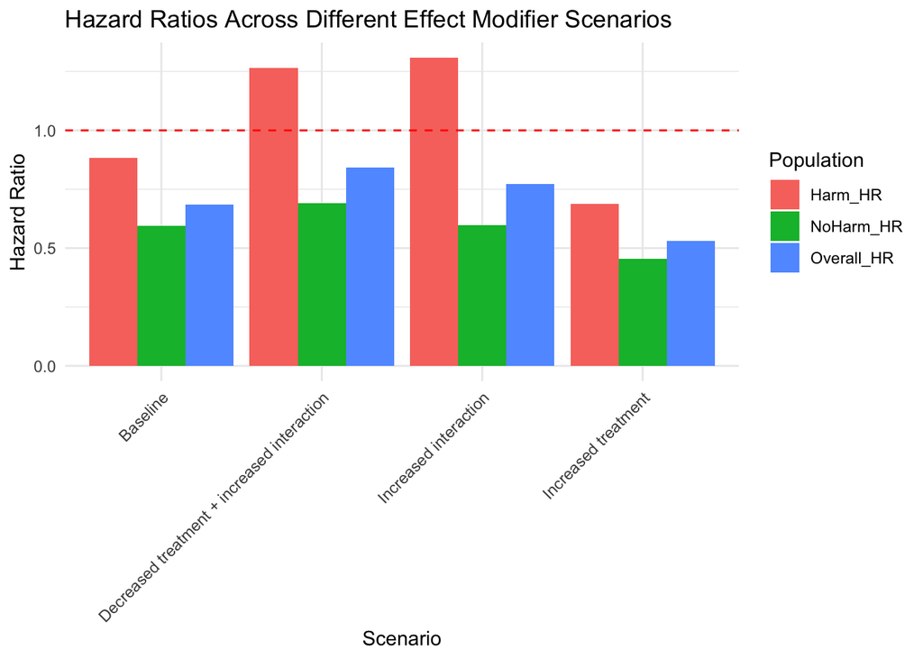

```r
# Visualize
library(tidyr)
library(dplyr)

results_long <- results %>%
  select(-k_treat, -k_inter) %>%
  pivot_longer(
    cols = c(Overall_HR, Harm_HR, NoHarm_HR),
    names_to = "Population",
    values_to = "HR"
  )

ggplot(results_long, aes(x = Scenario, y = HR, fill = Population)) +
  geom_bar(stat = "identity", position = "dodge") +
  geom_hline(yintercept = 1, linetype = "dashed", color = "red") +
  labs(
    title = "Hazard Ratios Across Different Effect Modifier Scenarios",
    x = "Scenario",
    y = "Hazard Ratio",
    fill = "Population"
  ) +
  theme_minimal() +
  theme(axis.text.x = element_text(angle = 45, hjust = 1))
```

# 10 Example 9: Simulating Data from DGM

This example shows how to generate simulated datasets from a DGM.

```r
# Create DGM
dgm9 <- generate_aft_dgm_flex(
  data = gbsg,
  continuous_vars = c("age", "size", "nodes", "pgr", "er"),
  factor_vars = c("meno", "grade"),
  outcome_var = "rfstime",
  event_var = "status",
  treatment_var = "hormon",
  subgroup_vars = c("er", "meno"),
  subgroup_cuts = list(er = 20, meno = 0),
  model = "alt",
  k_treat = 1.0,
  k_inter = 1.5,
  n_super = 10000,
  seed = 999,
  verbose = FALSE
)
```

```
 ======================================================================
 CENSORING MODEL SELECTION:
 MULTIPLE SURVIVAL REGRESSION MODEL COMPARISONS
======================================================================

CONVERGENCE SUMMARY ( 4 / 4  converged):
--------------------------------------------------

Weibull (weibull):
  Status:  ✓ Converged
  Iterations:  9
  Log-likelihood:  -3160.27
  Scale parameter:  0.418

LogNormal (lognormal):
  Status:  ✓ Converged
  Iterations:  4
  Log-likelihood:  -3322.175
  Scale parameter:  0.8707

Weibull0 (weibull):
  Status:  ✓ Converged
  Iterations:  7
  Log-likelihood:  -3165.584
  Scale parameter:  0.4246

LogNormal0 (lognormal):
  Status:  ✓ Converged
  Iterations:  6
  Log-likelihood:  -3326.192
  Scale parameter:  0.8768

MODEL COMPARISON TABLE:
--------------------------------------------------
      Model     AIC delta_AIC AIC_weight     BIC delta_BIC
   Weibull0 6335.17      0.00      0.976 6344.23      0.00
    Weibull 6342.54      7.37      0.024 6392.38     48.15
 LogNormal0 6656.38    321.22      0.000 6665.45    321.22
  LogNormal 6666.35    331.18      0.000 6716.19    371.96

MODEL RANKINGS:
--------------------------------------------------
By AIC:  Weibull0 > Weibull > LogNormal0 > LogNormal
By BIC:  Weibull0 > Weibull > LogNormal0 > LogNormal

EVIDENCE ASSESSMENT:
--------------------------------------------------
  Strength:  Strong evidence
  Details:  Top model has 97.6% of AIC weight

FINAL RECOMMENDATION:
--------------------------------------------------
  Clear winner: Weibull0 (best by both AIC and BIC)
  Evidence: Strong evidence - Top model has 97.6% of AIC weight
======================================================================
```

```r
# Simulate datasets with different parameters
sim1 <- simulate_from_dgm(
  dgm = dgm9,
  n = 500,
  rand_ratio = 1,
  max_entry = 12,
  analysis_time = 48,
  cens_adjust = 0,
  draw_treatment = TRUE,
  seed = 111
)

sim2 <- simulate_from_dgm(
  dgm = dgm9,
  n = 500,
  rand_ratio = 2,  # 2:1 randomization
  max_entry = 24,
  analysis_time = 48,
  cens_adjust = log(1.5),  # More censoring
  draw_treatment = TRUE,
  seed = 222
)

# Compare simulated datasets
cat("\nSimulation 1 (1:1 randomization, less censoring):\n")
```

```
Simulation 1 (1:1 randomization, less censoring):
```

```r
cat("Sample size:", nrow(sim1), "\n")
```

```
Sample size: 500
```

```r
cat("Treatment allocation:", table(sim1$treat_sim), "\n")
```

```
Treatment allocation: 250 250
```

```r
cat("Events:", sum(sim1$event_sim), "(",
    round(100 * mean(sim1$event_sim), 1), "%)\n")
```

```
Events: 2 ( 0.4 %)
```

```r
cat("Harm subgroup:", sum(sim1$flag_harm), "(",
    round(100 * mean(sim1$flag_harm), 1), "%)\n\n")
```

```
Harm subgroup: 88 ( 17.6 %)
```

```r
cat("Simulation 2 (2:1 randomization, more censoring):\n")
```

```
Simulation 2 (2:1 randomization, more censoring):
```

```r
cat("Sample size:", nrow(sim2), "\n")
```

```
Sample size: 500
```

```r
cat("Treatment allocation:", table(sim2$treat_sim), "\n")
```

```
Treatment allocation: 167 333
```

```r
cat("Events:", sum(sim2$event_sim), "(",
    round(100 * mean(sim2$event_sim), 1), "%)\n")
```

```
Events: 2 ( 0.4 %)
```

```r
cat("Harm subgroup:", sum(sim2$flag_harm), "(",
    round(100 * mean(sim2$flag_harm), 1), "%)\n")
```

```
Harm subgroup: 88 ( 17.6 %)
```

# 11 Example 10: Standardized vs Non-Standardized Covariates

This example compares models with and without covariate standardization.

```r
# Without standardization
dgm10_nostd <- generate_aft_dgm_flex(
  data = gbsg,
  continuous_vars = c("age", "size", "nodes"),
  factor_vars = c("meno"),
  outcome_var = "rfstime",
  event_var = "status",
  treatment_var = "hormon",
  subgroup_vars = c("age"),
  subgroup_cuts = list(age = 50),
  model = "alt",
  k_treat = 1.0,
  k_inter = 1.5,
  standardize = FALSE,  # No standardization
  n_super = 5000,
  seed = 1001,
  verbose = FALSE
)
```

```
 ======================================================================
 CENSORING MODEL SELECTION:
 MULTIPLE SURVIVAL REGRESSION MODEL COMPARISONS
======================================================================

CONVERGENCE SUMMARY ( 4 / 4  converged):
--------------------------------------------------

Weibull (weibull):
  Status:  ✓ Converged
  Iterations:  9
  Log-likelihood:  -3163.575
  Scale parameter:  0.4199

LogNormal (lognormal):
  Status:  ✓ Converged
  Iterations:  4
  Log-likelihood:  -3324.107
  Scale parameter:  0.8719

Weibull0 (weibull):
  Status:  ✓ Converged
  Iterations:  7
  Log-likelihood:  -3165.584
  Scale parameter:  0.4246

LogNormal0 (lognormal):
  Status:  ✓ Converged
  Iterations:  6
  Log-likelihood:  -3326.192
  Scale parameter:  0.8768

MODEL COMPARISON TABLE:
--------------------------------------------------
      Model     AIC delta_AIC AIC_weight     BIC delta_BIC
   Weibull0 6335.17      0.00      0.952 6344.23      0.00
    Weibull 6341.15      5.98      0.048 6372.87     28.64
 LogNormal0 6656.38    321.22      0.000 6665.45    321.22
  LogNormal 6662.21    327.05      0.000 6693.93    349.70

MODEL RANKINGS:
--------------------------------------------------
By AIC:  Weibull0 > Weibull > LogNormal0 > LogNormal
By BIC:  Weibull0 > Weibull > LogNormal0 > LogNormal

EVIDENCE ASSESSMENT:
--------------------------------------------------
  Strength:  Moderate evidence
  Details:  Top model has 95.2% of AIC weight

FINAL RECOMMENDATION:
--------------------------------------------------
  Clear winner: Weibull0 (best by both AIC and BIC)
  Evidence: Moderate evidence - Top model has 95.2% of AIC weight
======================================================================
```

```r
# With standardization
dgm10_std <- generate_aft_dgm_flex(
  data = gbsg,
  continuous_vars = c("age", "size", "nodes"),
  factor_vars = c("meno"),
  outcome_var = "rfstime",
  event_var = "status",
  treatment_var = "hormon",
  subgroup_vars = c("age"),
  subgroup_cuts = list(age = 50),
  model = "alt",
  k_treat = 1.0,
  k_inter = 1.5,
  standardize = TRUE,  # Standardize
  n_super = 5000,
  seed = 1001,
  verbose = FALSE
)
```

```
 ======================================================================
 CENSORING MODEL SELECTION:
 MULTIPLE SURVIVAL REGRESSION MODEL COMPARISONS
======================================================================

CONVERGENCE SUMMARY ( 4 / 4  converged):
--------------------------------------------------

Weibull (weibull):
  Status:  ✓ Converged
  Iterations:  9
  Log-likelihood:  -3163.575
  Scale parameter:  0.4199

LogNormal (lognormal):
  Status:  ✓ Converged
  Iterations:  4
  Log-likelihood:  -3324.107
  Scale parameter:  0.8719

Weibull0 (weibull):
  Status:  ✓ Converged
  Iterations:  7
  Log-likelihood:  -3165.584
  Scale parameter:  0.4246

LogNormal0 (lognormal):
  Status:  ✓ Converged
  Iterations:  6
  Log-likelihood:  -3326.192
  Scale parameter:  0.8768

MODEL COMPARISON TABLE:
--------------------------------------------------
      Model     AIC delta_AIC AIC_weight     BIC delta_BIC
   Weibull0 6335.17      0.00      0.952 6344.23      0.00
    Weibull 6341.15      5.98      0.048 6372.87     28.64
 LogNormal0 6656.38    321.22      0.000 6665.45    321.22
  LogNormal 6662.21    327.05      0.000 6693.93    349.70

MODEL RANKINGS:
--------------------------------------------------
By AIC:  Weibull0 > Weibull > LogNormal0 > LogNormal
By BIC:  Weibull0 > Weibull > LogNormal0 > LogNormal

EVIDENCE ASSESSMENT:
--------------------------------------------------
  Strength:  Moderate evidence
  Details:  Top model has 95.2% of AIC weight

FINAL RECOMMENDATION:
--------------------------------------------------
  Clear winner: Weibull0 (best by both AIC and BIC)
  Evidence: Moderate evidence - Top model has 95.2% of AIC weight
======================================================================
```

```r
# Compare coefficients
cat("Without standardization - gamma coefficients:\n")
```

```
Without standardization - gamma coefficients:
```

```r
print(round(dgm10_nostd$model_params$gamma, 4))
```

```
     treat      z_age     z_size    z_nodes     z_meno treat_harm
    0.2669     0.0106    -0.0063    -0.0412    -0.2584     0.1665
```

```r
cat("\nWith standardization - gamma coefficients:\n")
```

```
With standardization - gamma coefficients:
```

```r
print(round(dgm10_std$model_params$gamma, 4))
```

```
     treat      z_age     z_size    z_nodes     z_meno treat_harm
    0.2669     0.1074    -0.0897    -0.2258    -0.2584     0.1665
```

```r
cat("\nHazard ratios are consistent:\n")
```

```
Hazard ratios are consistent:
```

```r
cat("No standardization - Overall HR:",
    round(dgm10_nostd$hazard_ratios$overall, 3), "\n")
```

```
No standardization - Overall HR: 0.65
```

```r
cat("With standardization - Overall HR:",
    round(dgm10_std$hazard_ratios$overall, 3), "\n")
```

```
With standardization - Overall HR: 0.65
```

# 12 Summary

This document demonstrated 10 key use cases for `generate_aft_dgm_flex()`:

1. **Basic usage** with fixed cutpoints
2. **Quantile-based** cutpoints
3. **Function-based** cutpoints (median, mean)
4. **Range-based** cutpoints
5. **Greater-than** cutpoints
6. **Multiple categorical** values
7. **Null vs alternative** models
8. **Effect modifiers** (k_treat, k_inter)
9. **Simulating datasets** from DGM
10. **Standardization** effects

Each example can be adapted for specific research needs by adjusting:

- Covariate selections
- Subgroup definitions
- Effect modifiers
- Sample sizes
- Censoring mechanisms